# Data Analytics Practicals 7 & 8 ~NHANES health data analytics

Eryk Gloginski

21/04/2023

#In this practical (7,8 combined) you will work with real world health data from one of the world’s largest repositories of human health data. The National Health and Nutrition Examination Study (NHANES) is a decades-long epidemiological study of the health of the US population run by the CDC. Every two-years (an NHANES cycle: https://wwwn.cdc.gov/nchs/nhanes/Default.aspx, starting in 1999) thousands of participants are recruited and studied across multiple indicators of health and wellbeing using blood sampling, established medical techniques, questionnaires, etc. It is arguably the world’s richest resource of publicly available health data. Thousands of researchers from all over the world will mine, analyse, and make useful discoveries on these data these data every year…see the research paper (attached in Bb) published this month in the prestigious medical journal ‘JAMA’ that used NHANES data with analysis performed exclusively using R packages.

#The NHANES data are well structured although they do require a degree of wrangling but are CLEAN (data hygeine already done).

#You will be provided with some introductory code to get you going and then you will be required to perform complete sets of analyses together with visualisations & assumption checks using code from the previous practicals. Each analysis will be set as a seperate exercise. There are a total of 3 exercises.

#Practicals 7 and 8 are designed to be a bit more challenging than the previous practicals and will require more self-direction. You will be required to integrate learnings from previous practicals to complete these exercises along with figuring out some data wrangling steps to complete the analyses. *All of the analyses/statistical tests required for hypothesis testing have been used previously.

```r
#install.packages("tidyverse")
#install.packages("gridExtra") #this package helps to organize figure output from ggplot
#install.packages("nhanesA") #this package enables data files to be directly retreived & imported from the NHANES website and converted into R data tables.

library(nhanesA)
library(tidyverse)
library(gridExtra)
getwd()
```

```
## [1] "I:/Year 3/Semester 6/Data Analytics/Practicals/Practical7and8"
```

```r
#setwd("D:/Year 3/Semester 6/Data Analytics/Practicals/Practical7and8")
#getwd()
list.files()
```

```
## [1] "jama_aggarwal_2023_oi_230024_1679344297.26562.pdf"
## [2] "Pr7_8_erykgloginski_20230414.Rmd"
```

#Getting started with continuous NHANES and exploring using the nhanesA package.

#Exercise 1 (code is mostly provided).

#Here we’ll explore continuous NHANES data and look at basic body measurements along with blood pressure data. NHANES keeps its data in data files known as TABLES which are distributed across 5 different data_groups: DEMO (demographic as well as unique ID data) EXAM (examination data), LAB (laboratory analysis from blood samples), DIET (dietary data from questionnaires), Q (general health, disease and related questionnaire data).

#We’ll work with NHANES data from the 2017-2018 cycle. Note data tables from his cycle are named “xxx_J”.

#For this analysis, we are interested in data from the EXAMINATION data group for the 2017-2018 cycle.

```r
nhanesTables('EXAM', 2017)
```

```
##    Data.File.Name
## 1           BPX_J
## 2           BMX_J
## 3        OHXDEN_J
## 4        OHXREF_J
## 5        DXXFEM_J
## 6           DXX_J
## 7        DXXSPN_J
## 8           LUX_J
## 9         DXXAG_J
## 10         BPXO_J
## 11          AUX_J
## 12        AUXAR_J
## 13       AUXTYM_J
## 14       AUXWBR_J
##                                             Data.File.Description
## 1                                                  Blood Pressure
## 2                                                   Body Measures
## 3                                         Oral Health - Dentition
## 4                            Oral Health - Recommendation of Care
## 5                        Dual-Energy X-ray Absorptiometry - Femur
## 6                   Dual-Energy X-ray Absorptiometry - Whole Body
## 7                        Dual-Energy X-ray Absorptiometry - Spine
## 8                         Liver Ultrasound Transient Elastography
## 9  Dual-Energy X-ray Absorptiometry - Android/Gynoid Measurements
## 10                    Blood Pressure - Oscillometric Measurements
## 11                                                     Audiometry
## 12                                   Audiometry - Acoustic Reflex
## 13                                      Audiometry - Tympanometry
## 14                              Audiometry - Wideband Reflectance
```

```r
nhanesTables('DEMO', 2017)
```

```
##   Data.File.Name                    Data.File.Description
## 1         DEMO_J Demographic Variables and Sample Weights
```

#The variables of interest for analytsis are contained in these data tables. #To find out what variables are in each table and to get details on the specific variables, you have to acsess the metadata provided on the NHANES website- and look at the .DOC files. Yiu can diretcly access this using the command below:

```r
browseNHANES(2017, 'EXAM')
```

```r
browseNHANES(2017, 'DEMO')
```

#note that the variable SEQN is common to both. #This is the ‘Respondent Sequence Number’ or unique identifier for subjects in the dataset. It is included in all data tables and can be used as the common feature to merge the data tables.

#Now we’ll import both the body measures and demographics data tables into R.

```r
BMX_J  <- nhanes('BMX_J')
DEMO_J <- nhanes('DEMO_J')
head (BMX_J)
```

```
##    SEQN BMDSTATS BMXWT BMIWT BMXRECUM BMIRECUM BMXHEAD BMIHEAD BMXHT BMIHT
## 1 93703        1  13.7     3     89.6       NA      NA      NA  88.6    NA
## 2 93704        1  13.9    NA     95.0       NA      NA      NA  94.2    NA
## 3 93705        1  79.5    NA       NA       NA      NA      NA 158.3    NA
## 4 93706        1  66.3    NA       NA       NA      NA      NA 175.7    NA
## 5 93707        1  45.4    NA       NA       NA      NA      NA 158.4    NA
## 6 93708        1  53.5    NA       NA       NA      NA      NA 150.2    NA
##   BMXBMI BMXLEG BMILEG BMXARML BMIARML BMXARMC BMIARMC BMXWAIST BMIWAIST BMXHIP
## 1   17.5     NA     NA    18.0      NA    16.2      NA     48.2       NA     NA
## 2   15.7     NA     NA    18.6      NA    15.2      NA     50.0       NA     NA
## 3   31.7   37.0     NA    36.0      NA    32.0      NA    101.8       NA  110.0
## 4   21.5   46.6     NA    38.8      NA    27.0      NA     79.3       NA   94.4
## 5   18.1   38.1     NA    33.8      NA    21.5      NA     64.1       NA   83.0
## 6   23.7   31.8     NA    30.6      NA    27.4      NA     88.2       NA   90.1
##   BMIHIP
## 1     NA
## 2     NA
## 3     NA
## 4     NA
## 5     NA
## 6     NA
```

```r
head (DEMO_J)
```

```
##    SEQN SDDSRVYR RIDSTATR RIAGENDR RIDAGEYR RIDAGEMN RIDRETH1 RIDRETH3 RIDEXMON
## 1 93703       10        2        2        2       NA        5        6        2
## 2 93704       10        2        1        2       NA        3        3        1
## 3 93705       10        2        2       66       NA        4        4        2
## 4 93706       10        2        1       18       NA        5        6        2
## 5 93707       10        2        1       13       NA        5        7        2
## 6 93708       10        2        2       66       NA        5        6        2
##   RIDEXAGM DMQMILIZ DMQADFC DMDBORN4 DMDCITZN DMDYRSUS DMDEDUC3 DMDEDUC2
## 1       27       NA      NA        1        1       NA       NA       NA
## 2       33       NA      NA        1        1       NA       NA       NA
## 3       NA        2      NA        1        1       NA       NA        2
## 4      222        2      NA        1        1       NA       15       NA
## 5      158       NA      NA        1        1       NA        6       NA
## 6       NA        2      NA        2        1        7       NA        1
##   DMDMARTL RIDEXPRG SIALANG SIAPROXY SIAINTRP FIALANG FIAPROXY FIAINTRP MIALANG
```

[output cut: 27 more lines]

```r
dim (BMX_J)
```

```
## [1] 8704   21
```

```r
dim (DEMO_J)
```

```
## [1] 9254   46
```

#The variables we are most interested in are height, weight, body mass index, and waist circumfernece (from BMX_J) and age and gender from DEMO. From our meta data, we can identify these variables as: BMXHT,BMXWT,BMXBMI,BMXWAIST,RIDAGEYR,RIAGENDR.

```r
summary(BMX_J$BMXHT)
```

```
##    Min. 1st Qu.  Median    Mean 3rd Qu.    Max.    NA's
##    78.3   151.4   161.9   156.6   171.2   197.7     688
```

```r
summary(BMX_J$BMXWT)
```

```
##    Min. 1st Qu.  Median    Mean 3rd Qu.    Max.    NA's
##    3.20   43.10   67.75   65.14   85.60  242.60     124
```

```r
summary(BMX_J$BMXBMI)
```

```
##    Min. 1st Qu.  Median    Mean 3rd Qu.    Max.    NA's
##   12.30   20.40   25.80   26.58   31.30   86.20     699
```

```r
summary(BMX_J$BMXWAIST)
```

```
##    Min. 1st Qu.  Median    Mean 3rd Qu.    Max.    NA's
##   40.00   73.90   91.20   89.93  105.30  169.50    1103
```

```r
summary(DEMO_J$RIDAGEYR)
```

```
##    Min. 1st Qu.  Median    Mean 3rd Qu.    Max.
##    0.00   11.00   31.00   34.33   58.00   80.00
```

```r
summary(DEMO_J$RIAGENDR)
```

```
##    Min. 1st Qu.  Median    Mean 3rd Qu.    Max.
##   1.000   1.000   2.000   1.508   2.000   2.000
```

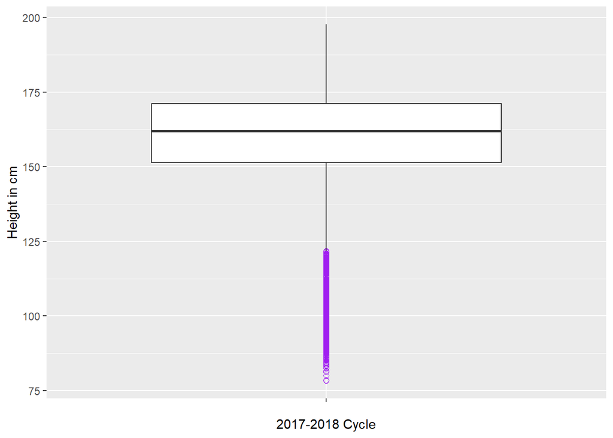

```r
Heightbox <- ggplot(BMX_J, aes(x="", y=BMXHT)) +
  geom_boxplot(outlier.colour="purple", outlier.shape=1,
                outlier.size=2) +
ylab("Height in cm")+
  xlab("2017-2018 Cycle")

Weightbox <- ggplot(BMX_J, aes(x="", y=BMXWT)) +
  geom_boxplot(outlier.colour="red", outlier.shape=1,
                outlier.size=2) +
ylab("Weight in kg")+
  xlab("2017-2018 Cycle")

BMIbox <- ggplot(BMX_J, aes(x="", y=BMXBMI)) +
  geom_boxplot(outlier.colour="cyan", outlier.shape=1,
                outlier.size=2) +
ylab("BMI kg/m2")+
  xlab("2017-2018 Cycle")

Waistbox <- ggplot(BMX_J, aes(x="", y=BMXWAIST)) +
  geom_boxplot(outlier.colour="green", outlier.shape=1,
                outlier.size=2) +
ylab("Waist circ in cm")+
  xlab("2017-2018 Cycle")

Agebox <- ggplot(DEMO_J, aes(x="", y=RIDAGEYR)) +
  geom_boxplot(outlier.colour="green", outlier.shape=1,
                outlier.size=2) +
ylab("Age in Yrs")+
  xlab("2017-2018 Cycle")

Heightbox
```

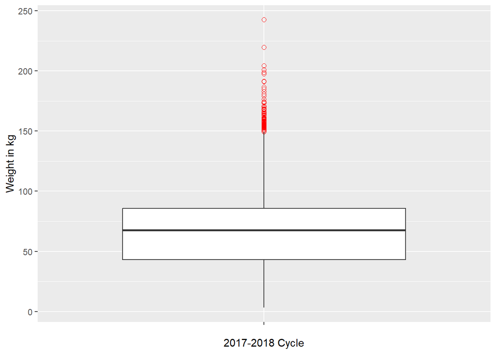

```r
Weightbox
```

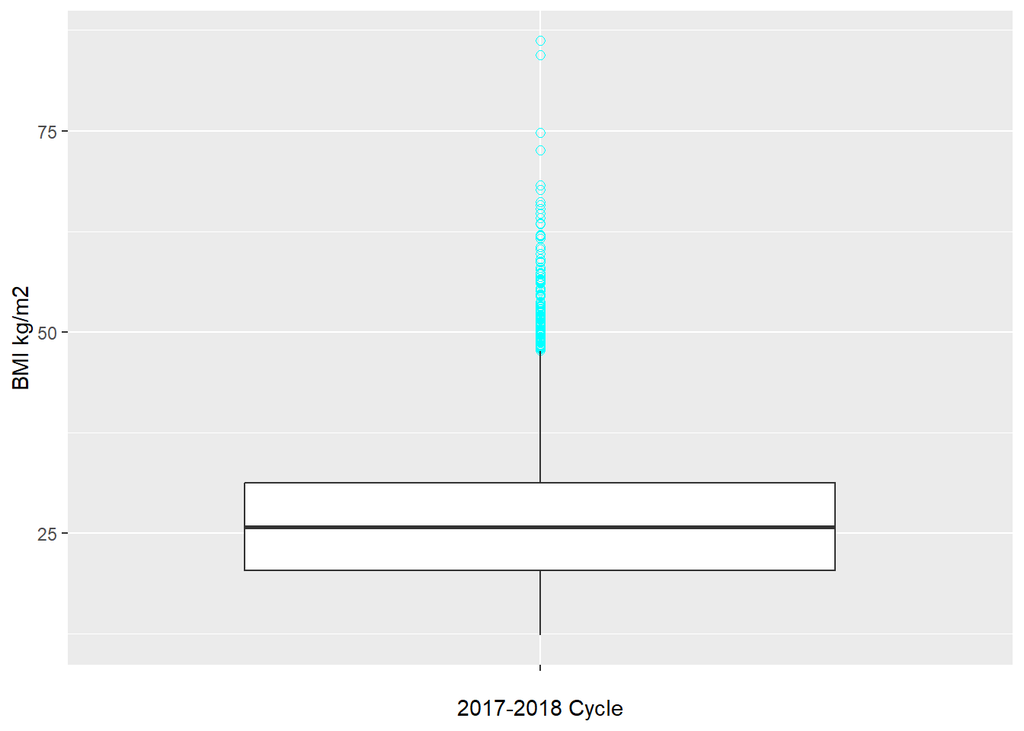

```r
BMIbox
```

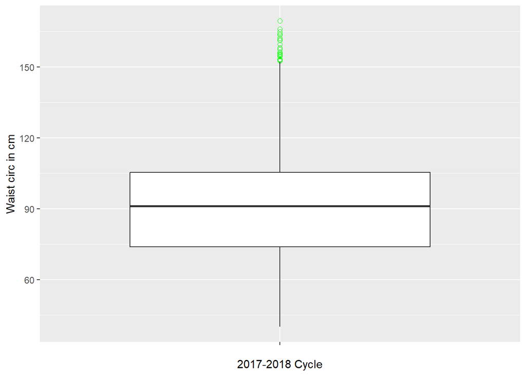

```r
Waistbox
```

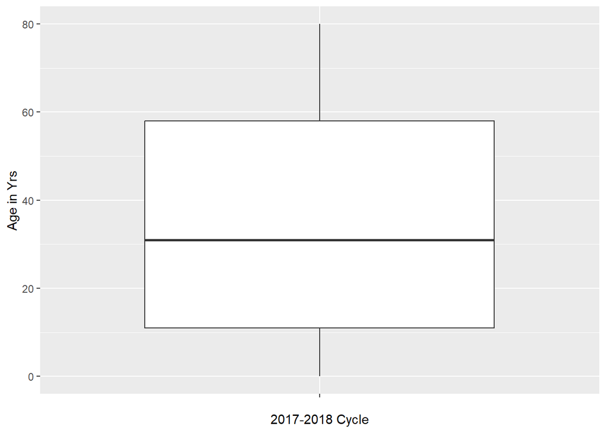

```r
Agebox
```

#There are clearly outliers in the data.

#to perfrom soem basic analyses, we need to merge these two data tables.

```r
MergedData2017 <- merge(DEMO_J, BMX_J, all=TRUE)
dim(MergedData2017)
```

```
## [1] 9254   66
```

```r
head(MergedData2017)
```

```
##    SEQN SDDSRVYR RIDSTATR RIAGENDR RIDAGEYR RIDAGEMN RIDRETH1 RIDRETH3 RIDEXMON
## 1 93703       10        2        2        2       NA        5        6        2
## 2 93704       10        2        1        2       NA        3        3        1
## 3 93705       10        2        2       66       NA        4        4        2
## 4 93706       10        2        1       18       NA        5        6        2
## 5 93707       10        2        1       13       NA        5        7        2
## 6 93708       10        2        2       66       NA        5        6        2
##   RIDEXAGM DMQMILIZ DMQADFC DMDBORN4 DMDCITZN DMDYRSUS DMDEDUC3 DMDEDUC2
## 1       27       NA      NA        1        1       NA       NA       NA
## 2       33       NA      NA        1        1       NA       NA       NA
## 3       NA        2      NA        1        1       NA       NA        2
## 4      222        2      NA        1        1       NA       15       NA
## 5      158       NA      NA        1        1       NA        6       NA
## 6       NA        2      NA        2        1        7       NA        1
##   DMDMARTL RIDEXPRG SIALANG SIAPROXY SIAINTRP FIALANG FIAPROXY FIAINTRP MIALANG
```

[output cut: 41 more lines]

#1. Test hypothesis 1: The BMI of adult males and adult females is different. H0: Male BMI = Female BMI.

```r
nhanesTranslate('DEMO_J', 'RIAGENDR')
```

```
## $RIAGENDR
##   Code.or.Value Value.Description
## 1             1              Male
## 2             2            Female
## 3             .           Missing
```

#we see that males are coded as 1 and females as 2.

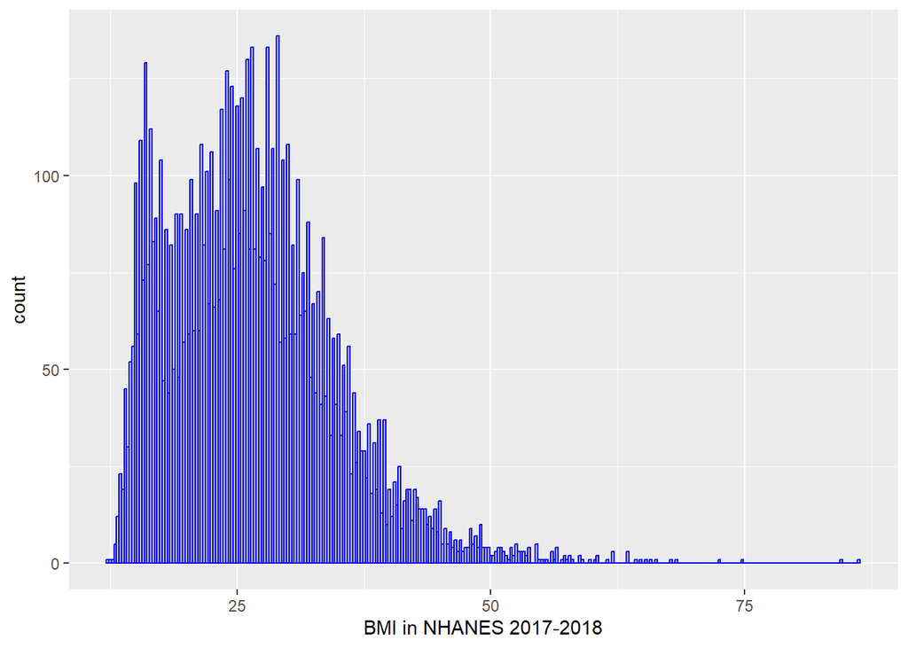

```r
BMIHist <- ggplot(MergedData2017, aes (x=BMXBMI)) +
      geom_histogram(binwidth=0.25, fill="grey", color="blue") +
        xlab("BMI in NHANES 2017-2018")

BMIHist
```

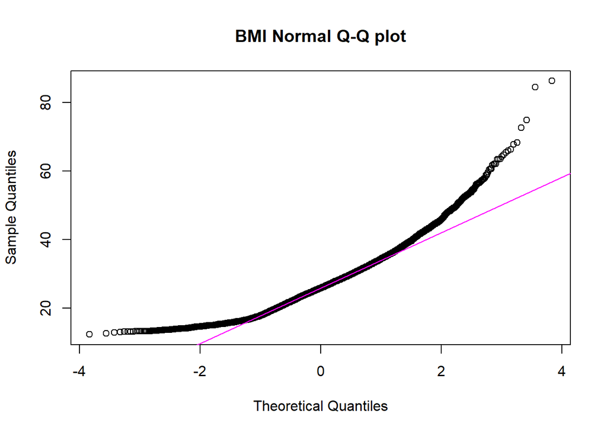

```r
BMINorm<- qqnorm(MergedData2017$BMXBMI, main = "BMI Normal Q-Q plot")
qqline(MergedData2017$BMXBMI, col="magenta")
```

#The data distribution does not look good, so we can try a log transformation of BMI.

```r
MergedData2017$logBMXBMI=log(MergedData2017$BMXBMI)
```

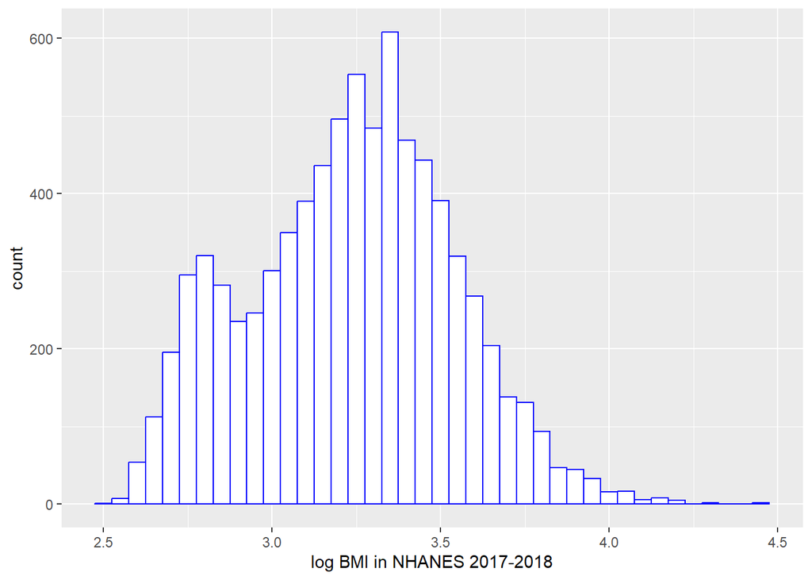

```r
BMIHist2 <- ggplot(MergedData2017, aes (x=logBMXBMI)) +
      geom_histogram(binwidth=0.05, fill="white", color="blue") +
        xlab("log BMI in NHANES 2017-2018")

BMIHist2
```

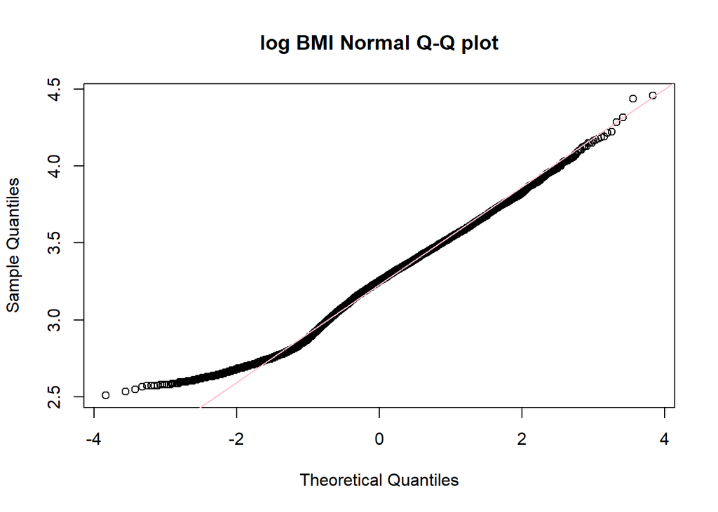

```r
BMINorm2<- qqnorm(MergedData2017$logBMXBMI, main = "log BMI Normal Q-Q plot")
qqline(MergedData2017$logBMXBMI, col="pink")
```

#The log transformed data clearly conform better to a normal distribution but there is still a problematic left skew in the data. #Do you notice anything odd about the histogram- hint: “a brace of peaks”. #What is the cause of this left skew? ##ANSWER: This is an example of a bimodal distribution- two peaks- one around 3.35 and the other at 2.8- there are actually two different BMI population distributions in the data. ##One distibution is the adult BMI distribution, the other is the fact that we have children in the sample, therefore the left skew relates to this fact. This will not always be the case but can often occur when we have a mixed sample of adults and children, or healthy vs diseased, or even sometimes, male vs female. #The fix here is easy, we should remove the chidlren from the data analysis as we are more interested only in adults. Here we will use age of 19yrs or greater to deffine an adult.

```r
MergedData2017A <- subset(MergedData2017, RIDAGEYR >= 19)
dim(MergedData2017A)
```

```
## [1] 5712   67
```

```r
head(MergedData2017A)
```

```
##     SEQN SDDSRVYR RIDSTATR RIAGENDR RIDAGEYR RIDAGEMN RIDRETH1 RIDRETH3
## 3  93705       10        2        2       66       NA        4        4
## 6  93708       10        2        2       66       NA        5        6
## 7  93709       10        2        2       75       NA        4        4
## 9  93711       10        2        1       56       NA        5        6
## 11 93713       10        2        1       67       NA        3        3
## 12 93714       10        2        2       54       NA        4        4
##    RIDEXMON RIDEXAGM DMQMILIZ DMQADFC DMDBORN4 DMDCITZN DMDYRSUS DMDEDUC3
## 3         2       NA        2      NA        1        1       NA       NA
## 6         2       NA        2      NA        2        1        7       NA
## 7         1       NA        2      NA        1        1       NA       NA
## 9         2       NA        2      NA        2        1        6       NA
## 11        1       NA        1       1        1        1       NA       NA
## 12        2       NA        2      NA        1        1       NA       NA
##    DMDEDUC2 DMDMARTL RIDEXPRG SIALANG SIAPROXY SIAINTRP FIALANG FIAPROXY
```

[output cut: 41 more lines]

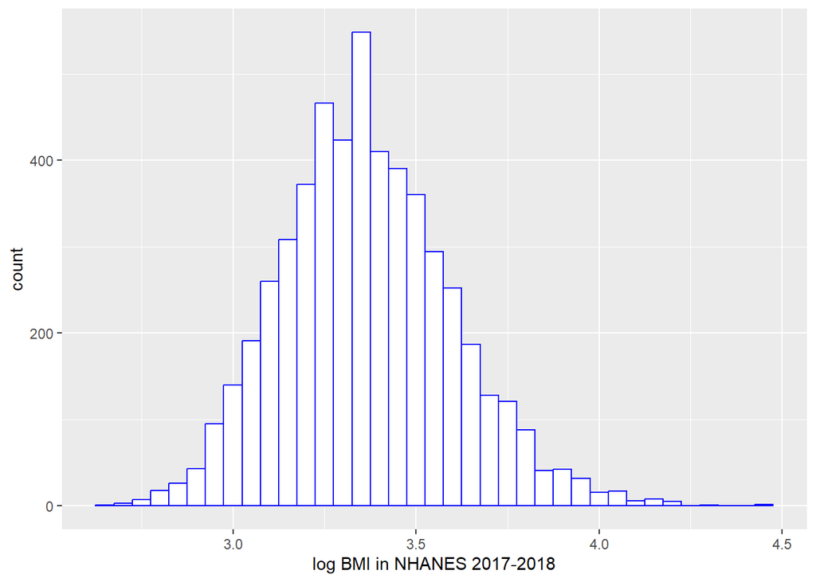

```r
BMIHist3 <- ggplot(MergedData2017A, aes (x=logBMXBMI)) +
      geom_histogram(binwidth=0.05, fill="white", color="blue") +
        xlab("log BMI in NHANES 2017-2018")

BMIHist3
```

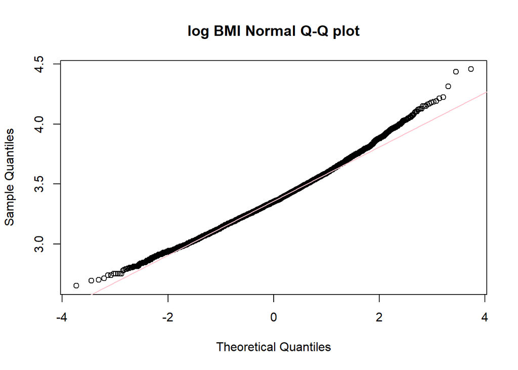

```r
BMINorm3<- qqnorm(MergedData2017A$logBMXBMI, main = "log BMI Normal Q-Q plot")
qqline(MergedData2017A$logBMXBMI, col="pink")
```

#The data look much better now, although there are clearly some very high BMI values (this is US data!) #We can now use a parametric statistic to test our null hypothesis (i.e. mean adult male and female BMIs are equal). #In this case we can use a t-test.

```r
res.ftest <- var.test(logBMXBMI ~ RIAGENDR, data = MergedData2017A)
res.ftest
```

```
##
##  F test to compare two variances
##
## data:  logBMXBMI by RIAGENDR
## F = 0.70228, num df = 2555, denom df = 2744, p-value < 2.2e-16
## alternative hypothesis: true ratio of variances is not equal to 1
## 95 percent confidence interval:
##  0.6507720 0.7579356
## sample estimates:
## ratio of variances
##          0.7022759
```

```r
t.test (logBMXBMI ~ RIAGENDR, var.equal=FALSE, data = MergedData2017A)
```

```
##
##  Welch Two Sample t-test
##
## data:  logBMXBMI by RIAGENDR
## t = -3.2946, df = 5241.7, p-value = 0.0009921
## alternative hypothesis: true difference in means between group 1 and group 2 is not equal to 0
## 95 percent confidence interval:
##  -0.033548444 -0.008517587
## sample estimates:
## mean in group 1 mean in group 2
##        3.354643        3.375676
```

#Based on a p-value of 0.00099, we can reject the null and conclude that there is a difference in BMI between adult males and females.

#2. Test hypothesis 2: There is a linear relationship between waist circumference and BMI. Ho: No linear relationship between BMI and waist.

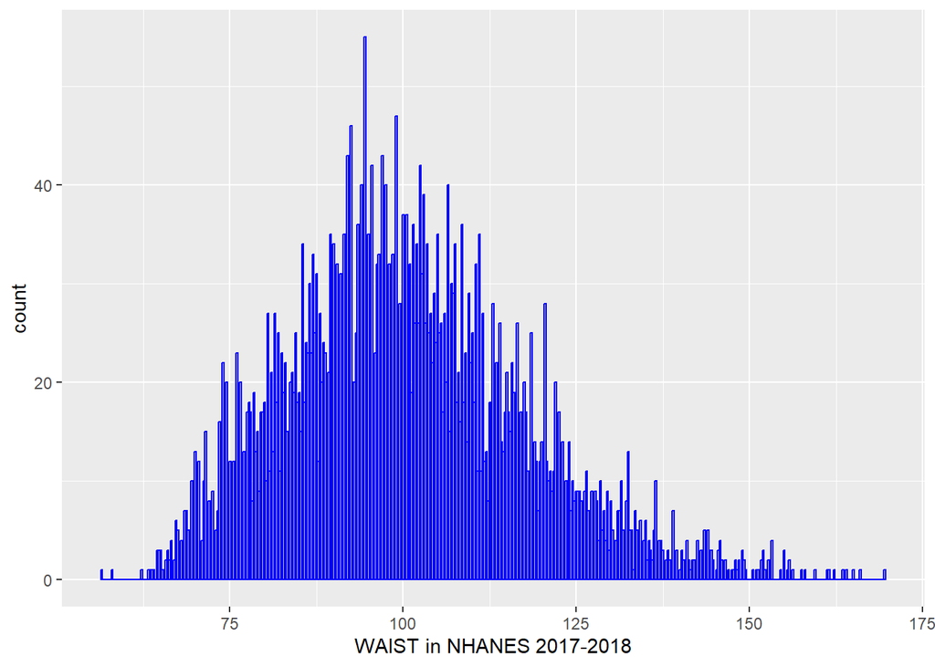

```r
WaistHist <- ggplot(MergedData2017A, aes (x=BMXWAIST)) +
      geom_histogram(binwidth=0.25, fill="grey", color="blue") +
        xlab("WAIST in NHANES 2017-2018")

WaistHist
```

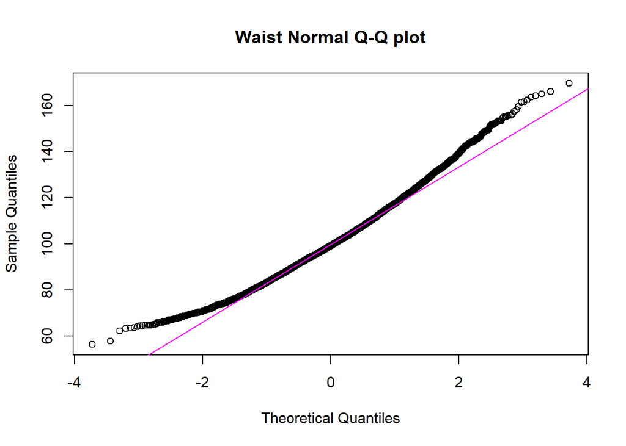

```r
WaisttNorm<- qqnorm(MergedData2017A$BMXWAIST, main = "Waist Normal Q-Q plot")
qqline(MergedData2017A$BMXWAIST, col="magenta")
```

#the data show some evidence for deviation form normal, so a log transformation may help.

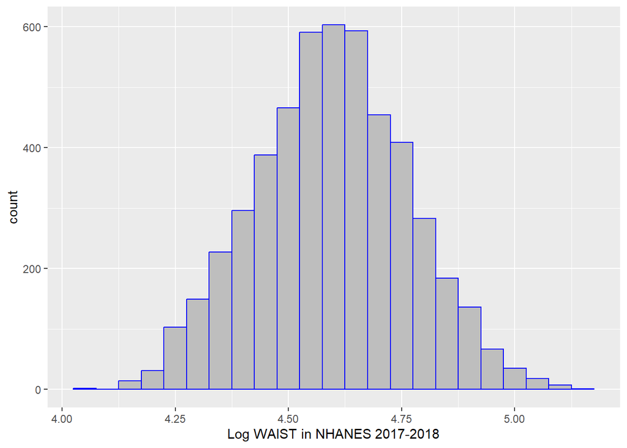

```r
MergedData2017A$logBMXWAIST=log(MergedData2017A$BMXWAIST)

logWaistHist <- ggplot(MergedData2017A, aes (x=logBMXWAIST)) +
      geom_histogram(binwidth=0.05, fill="grey", color="blue") +
        xlab("Log WAIST in NHANES 2017-2018")

logWaistHist
```

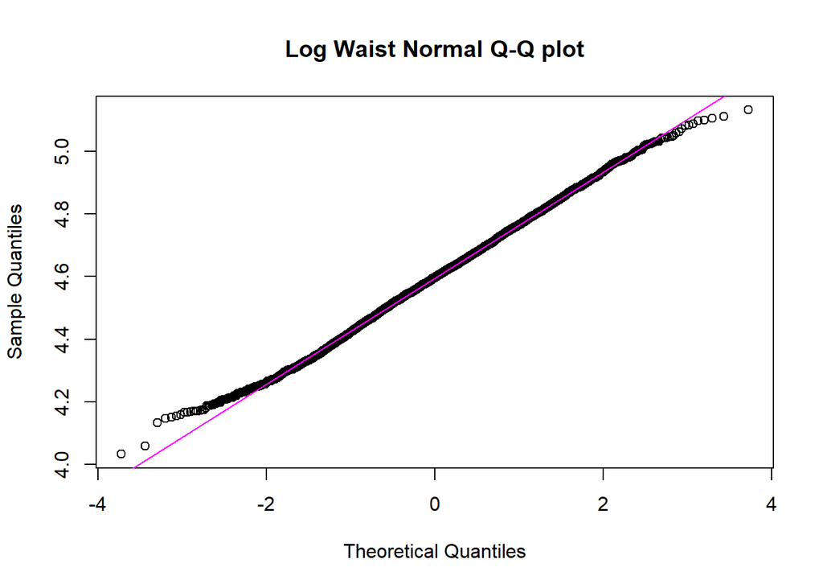

```r
logWaisttNorm<- qqnorm(MergedData2017A$logBMXWAIST, main = "Log Waist Normal Q-Q plot")
qqline(MergedData2017A$logBMXWAIST, col="magenta")
```

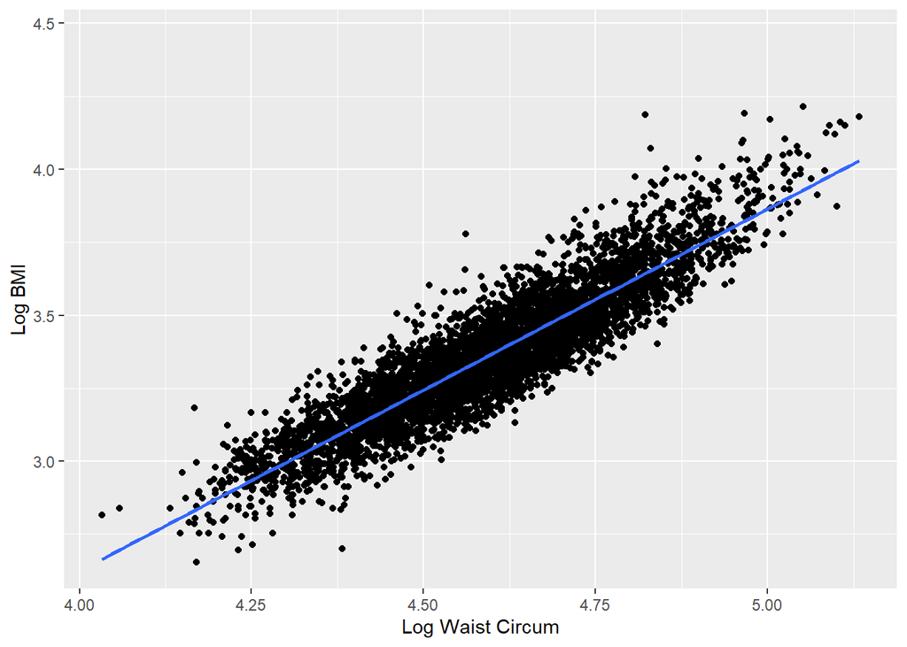

```r
scatter_plot <- ggplot(MergedData2017A, aes(x = logBMXWAIST, y = logBMXBMI)) +
    geom_point() +
   geom_smooth(method = "lm", se = FALSE) +
    xlab("Log Waist Circum") +
  ylab("Log BMI")
scatter_plot
```

```r
BMI_waist_MODEL <- lm(formula= logBMXBMI ~ logBMXWAIST, data=MergedData2017A)
summary(BMI_waist_MODEL)
```

```
##
## Call:
## lm(formula = logBMXBMI ~ logBMXWAIST, data = MergedData2017A)
##
## Residuals:
##      Min       1Q   Median       3Q      Max
## -0.39622 -0.06564 -0.00440  0.05985  0.54330
##
## Coefficients:
##              Estimate Std. Error t value Pr(>|t|)
## (Intercept) -2.339157   0.036412  -64.24   <2e-16 ***
## logBMXWAIST  1.240691   0.007918  156.70   <2e-16 ***
## ---
## Signif. codes:  0 '***' 0.001 '**' 0.01 '*' 0.05 '.' 0.1 ' ' 1
##
## Residual standard error: 0.09495 on 5046 degrees of freedom
##   (664 observations deleted due to missingness)
## Multiple R-squared:  0.8295, Adjusted R-squared:  0.8295
## F-statistic: 2.455e+04 on 1 and 5046 DF,  p-value: < 2.2e-16
```

#there is a strong linear relationship (P<0.0001) with a high R2 value of 0.83.

#Now we need to do some diagnostics on the regression residuals to check that no linear regression assumptions were violated.

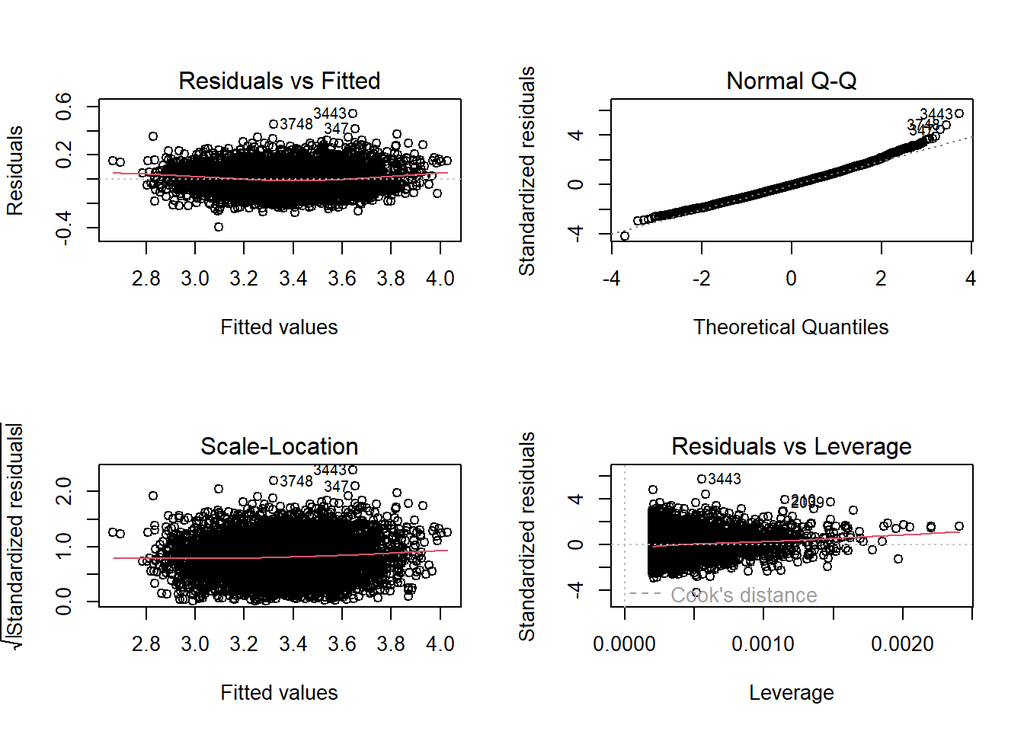

```r
par(mfrow=c(2,2))
plot(BMI_waist_MODEL)
```

```r
par(mfrow=c(1,1))
```

# 1. Residuals vs. Fitted: this tells us that the mean of the errors is zero across all fitted values, indeed the output above gave us the median of the residuals(errors) as -0.00440- very clode to zero). Therefore this key assumption (assumption 1 from lecture 13) is not violated.

# 2. The Normal Q-Q plot shows us that the residuals largely conform to a normal distribution: errors are normally distributed.

# 3. The scale location plot tells us the scale of variability of errors is constant over all values.

# 4. The Residuals vs leverage plot shows a metric known as Cook’s distance: this helps highlight any overly influential data points tmay not be valid(like outliers) and can also be used to to indicate regions of the data distributions in which more data swould be beneficial.The plot shows data well within the Cook’s distance but does suggest a limited density of data at the upper end of the data space, i.e. at the higher values of both variables- this means we should exert some caution on use of the model for making predictions at the higher values of waist circumference.

# 5. We can asssume that the explanatory/predictor variables in this case were collected without error as NHANES methods are very well established.

##In summary, we have a strong model and it is clear that there is a strong linear relationship between BMI and waist in adults.

#**************************************************************************************************************** #****************************************************************************************************************

#Exercise 2.

#There are typically 5 categories of body mass index (BMI) used in adults. # 1. Underweight: BMI<18.50 # 2. Normal weight: BMI 18.50-24.99 # 3. Overweight: BMI 25.00-29.99 # 4. Obesity (obese): BMI 30.00-39.99 # 5. Severe Obesity: BMI = 40.0 or greater.

#Using data from NHANES 2015-2016, test the following 5 hypotheses (making sure to perform data hygeine steps up front):

# 1. There is no age difference among normal weight, overweight, and obese adults.

# 2. The proportion of male and female adults who are severely obese is the same.

# 3. The proportion of males in the overweight, obesity, and severe obesity categories is the same.

# 4. There is a linear relationship between Systolic Blood Pressure and BMI in adults (BMI is a predictor of systolic blood pressure).

# 5. Total cholesterol concentrations do not differ among normal weight, overweight,and obese (obesity) adults.

```r
# Explore NHANES
nhanesTables('EXAM', 2015)
```

```
##    Data.File.Name
## 1           BPX_I
## 2           BMX_I
## 3        OHXDEN_I
## 4        OHXREF_I
## 5        FLXCLN_I
## 6           AUX_I
## 7           DXX_I
## 8         AUXAR_I
## 9        AUXTYM_I
## 10       AUXWBR_I
## 11        DXXAG_I
##                                             Data.File.Description
## 1                                                  Blood Pressure
## 2                                                   Body Measures
## 3                                         Oral Health - Dentition
## 4                            Oral Health - Recommendation of Care
## 5                                            Fluorosis - Clinical
## 6                                                      Audiometry
## 7                   Dual-Energy X-ray Absorptiometry - Whole Body
## 8                                    Audiometry - Acoustic Reflex
## 9                                       Audiometry - Tympanometry
## 10                              Audiometry – Wideband Reflectance
## 11 Dual-Energy X-ray Absorptiometry - Android/Gynoid Measurements
```

```r
nhanesTables('DEMO', 2015)
```

```
##   Data.File.Name                    Data.File.Description
## 1         DEMO_I Demographic Variables and Sample Weights
```

```r
#browseNHANES(2015, 'EXAM')
#browseNHANES(2015, 'DEMO')

# Get Data
BMX_I  <- nhanes('BMX_I')
DEMO_I <- nhanes('DEMO_I')

# Check Data
head(BMX_I)
```

```
##    SEQN BMDSTATS BMXWT BMIWT BMXRECUM BMIRECUM BMXHEAD BMIHEAD BMXHT BMIHT
## 1 83732        1  94.8    NA       NA       NA      NA      NA 184.5    NA
## 2 83733        1  90.4    NA       NA       NA      NA      NA 171.4    NA
## 3 83734        1  83.4    NA       NA       NA      NA      NA 170.1    NA
## 4 83735        1 109.8    NA       NA       NA      NA      NA 160.9    NA
## 5 83736        3  55.2    NA       NA       NA      NA      NA 164.9    NA
## 6 83737        1  64.4    NA       NA       NA      NA      NA 150.0    NA
##   BMXBMI BMDBMIC BMXLEG BMILEG BMXARML BMIARML BMXARMC BMIARMC BMXWAIST
## 1   27.8      NA   43.3     NA    43.6      NA    35.9      NA    101.1
## 2   30.8      NA   38.0     NA    40.0      NA    33.2      NA    107.9
## 3   28.8      NA   35.6     NA    37.0      NA    31.0      NA    116.5
## 4   42.4      NA   38.5     NA    37.7      NA    38.3      NA    110.1
## 5   20.3      NA   37.4     NA    36.0      NA    27.2      NA     80.4
## 6   28.6      NA   34.4     NA    33.5      NA    31.4      NA     92.9
##   BMIWAIST BMXSAD1 BMXSAD2 BMXSAD3 BMXSAD4 BMDAVSAD BMDSADCM
## 1       NA    22.9    22.7      NA      NA     22.8       NA
## 2       NA    27.5    27.1      NA      NA     27.3       NA
## 3       NA    26.7    26.5      NA      NA     26.6       NA
## 4       NA    25.2    25.0      NA      NA     25.1       NA
## 5       NA      NA      NA      NA      NA       NA       NA
## 6       NA    23.2    23.0      NA      NA     23.1       NA
```

```r
head(DEMO_I)
```

```
##    SEQN SDDSRVYR RIDSTATR RIAGENDR RIDAGEYR RIDAGEMN RIDRETH1 RIDRETH3 RIDEXMON
## 1 83732        9        2        1       62       NA        3        3        1
## 2 83733        9        2        1       53       NA        3        3        1
## 3 83734        9        2        1       78       NA        3        3        2
## 4 83735        9        2        2       56       NA        3        3        2
## 5 83736        9        2        2       42       NA        4        4        2
## 6 83737        9        2        2       72       NA        1        1        1
##   RIDEXAGM DMQMILIZ DMQADFC DMDBORN4 DMDCITZN DMDYRSUS DMDEDUC3 DMDEDUC2
## 1       NA        2      NA        1        1       NA       NA        5
## 2       NA        2      NA        2        2        7       NA        3
## 3       NA        1       2        1        1       NA       NA        3
## 4       NA        2      NA        1        1       NA       NA        5
## 5       NA        2      NA        1        1       NA       NA        4
## 6       NA        2      NA        2        2        2       NA        2
##   DMDMARTL RIDEXPRG SIALANG SIAPROXY SIAINTRP FIALANG FIAPROXY FIAINTRP MIALANG
```

[output cut: 27 more lines]

```r
dim(BMX_I)
```

```
## [1] 9544   26
```

```r
dim(DEMO_I)
```

```
## [1] 9971   47
```

```r
# Merge Data
MERGED_DATA <- merge(DEMO_I, BMX_I, all=TRUE)
dim(MERGED_DATA)
```

```
## [1] 9971   72
```

```r
head(MERGED_DATA)
```

```
##    SEQN SDDSRVYR RIDSTATR RIAGENDR RIDAGEYR RIDAGEMN RIDRETH1 RIDRETH3 RIDEXMON
## 1 83732        9        2        1       62       NA        3        3        1
## 2 83733        9        2        1       53       NA        3        3        1
## 3 83734        9        2        1       78       NA        3        3        2
## 4 83735        9        2        2       56       NA        3        3        2
## 5 83736        9        2        2       42       NA        4        4        2
## 6 83737        9        2        2       72       NA        1        1        1
##   RIDEXAGM DMQMILIZ DMQADFC DMDBORN4 DMDCITZN DMDYRSUS DMDEDUC3 DMDEDUC2
## 1       NA        2      NA        1        1       NA       NA        5
## 2       NA        2      NA        2        2        7       NA        3
## 3       NA        1       2        1        1       NA       NA        3
## 4       NA        2      NA        1        1       NA       NA        5
## 5       NA        2      NA        1        1       NA       NA        4
## 6       NA        2      NA        2        2        2       NA        2
##   DMDMARTL RIDEXPRG SIALANG SIAPROXY SIAINTRP FIALANG FIAPROXY FIAINTRP MIALANG
```

[output cut: 48 more lines]

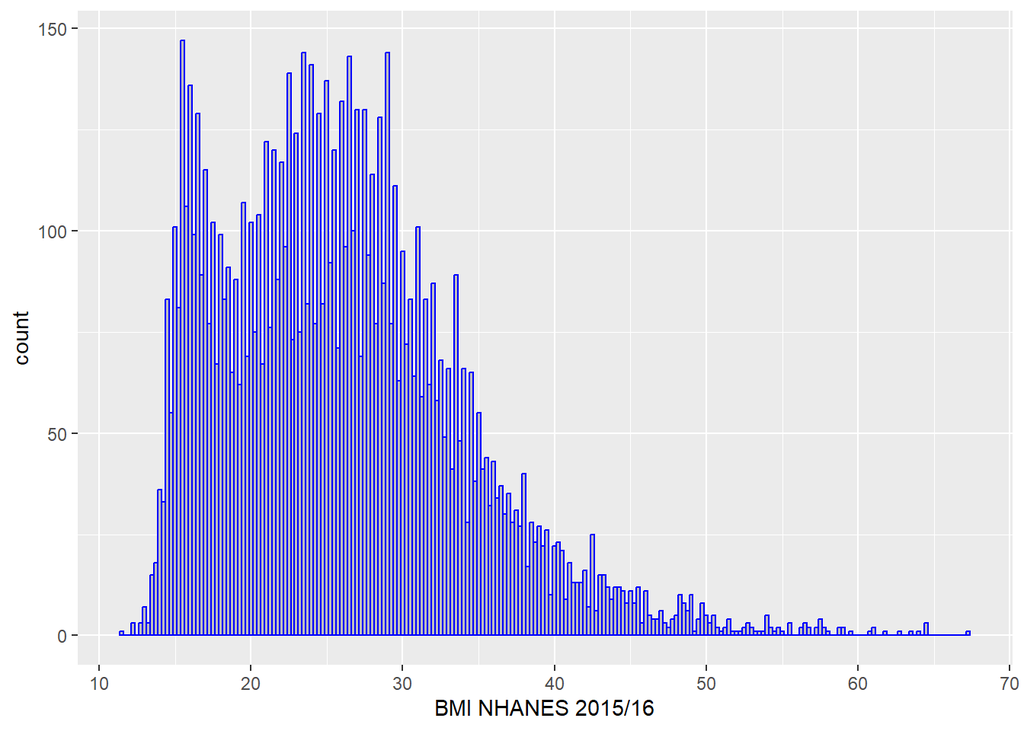

```r
# Make histogram using ggplot and BMXBMI
BMI_HISTOGRAM_1 <- ggplot(MERGED_DATA, aes (x=BMXBMI)) +
  geom_histogram(binwidth=0.25, fill="grey", color="blue") +
  xlab("BMI NHANES 2015/16")

# Display Histogram
BMI_HISTOGRAM_1
```

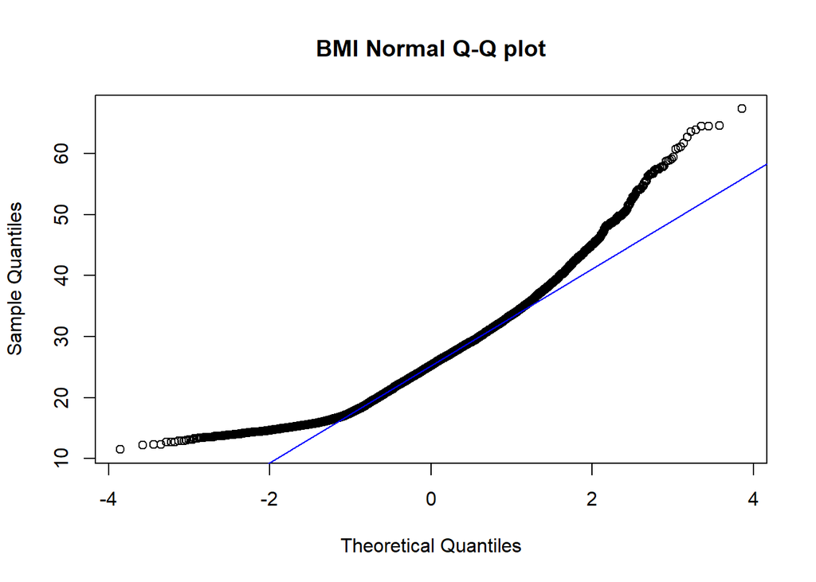

```r
# Normal probablity plot
BMI_NORM_QQ_1 <- qqnorm(MERGED_DATA$BMXBMI, main = "BMI Normal Q-Q plot")
qqline(MERGED_DATA$BMXBMI, col="blue")
```

```r
MERGED_DATA$logBMXBMI=log(MERGED_DATA$BMXBMI)

# T test
t.test (logBMXBMI ~ RIAGENDR, var.equal=FALSE, data = MERGED_DATA)
```

```
##
##  Welch Two Sample t-test
##
## data:  logBMXBMI by RIAGENDR
## t = -5.1377, df = 8736.2, p-value = 2.841e-07
## alternative hypothesis: true difference in means between group 1 and group 2 is not equal to 0
## 95 percent confidence interval:
##  -0.04522702 -0.02024645
## sample estimates:
## mean in group 1 mean in group 2
##        3.197127        3.229864
```

```r
#2
# Filtered by severe obesity
MERGED_DATA_SEVERE_OBESITY <- subset(MERGED_DATA, BMXBMI >= 40)
dim(MERGED_DATA_SEVERE_OBESITY)
```

```
## [1] 478  73
```

```r
head(MERGED_DATA_SEVERE_OBESITY)
```

[output not shown]

[output cut: 48 more lines]

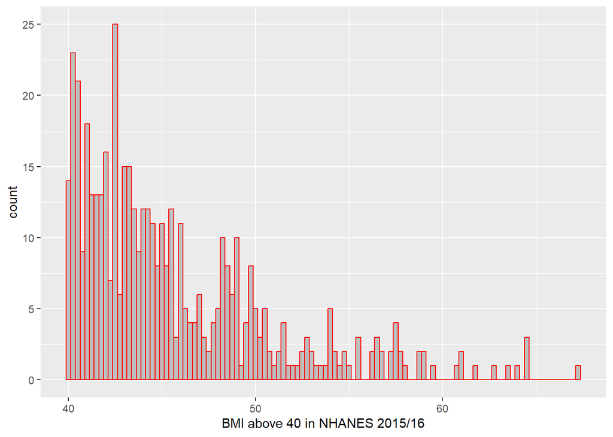

```r
# Histogram for severe obesity using BMXBMI
BMI_HISTOGRAM_2 <- ggplot(MERGED_DATA_SEVERE_OBESITY, aes (x=BMXBMI)) +
  geom_histogram(binwidth=0.25, fill="grey", color="red") +
  xlab("BMI above 40 in NHANES 2015/16")

BMI_HISTOGRAM_2
```

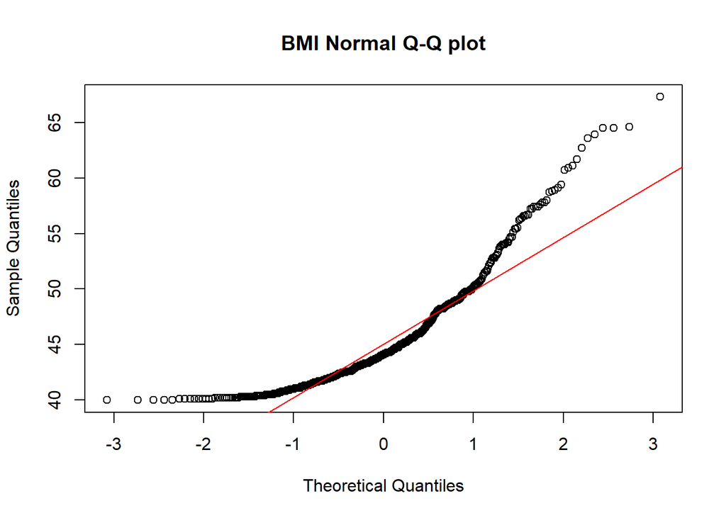

```r
# Normal probablity plot
BMI_NORM_QQ_2 <- qqnorm(MERGED_DATA_SEVERE_OBESITY$BMXBMI, main = "BMI Normal Q-Q plot")
qqline(MERGED_DATA_SEVERE_OBESITY$BMXBMI, col="red")
```

```r
# filtered by gender
MERGED_DATA_GENDER <- table(MERGED_DATA$BMXBMI, MERGED_DATA$RIAGENDR)
MERGED_DATA_GENDER
```

[output not shown]

[output cut: 376 more lines]

[output not shown]

```r
#chi squared test of independence
chisq.test(MERGED_DATA_GENDER)
```

```
##
##  Pearson's Chi-squared test
##
## data:  MERGED_DATA_GENDER
## X-squared = 484.45, df = 428, p-value = 0.03052
```

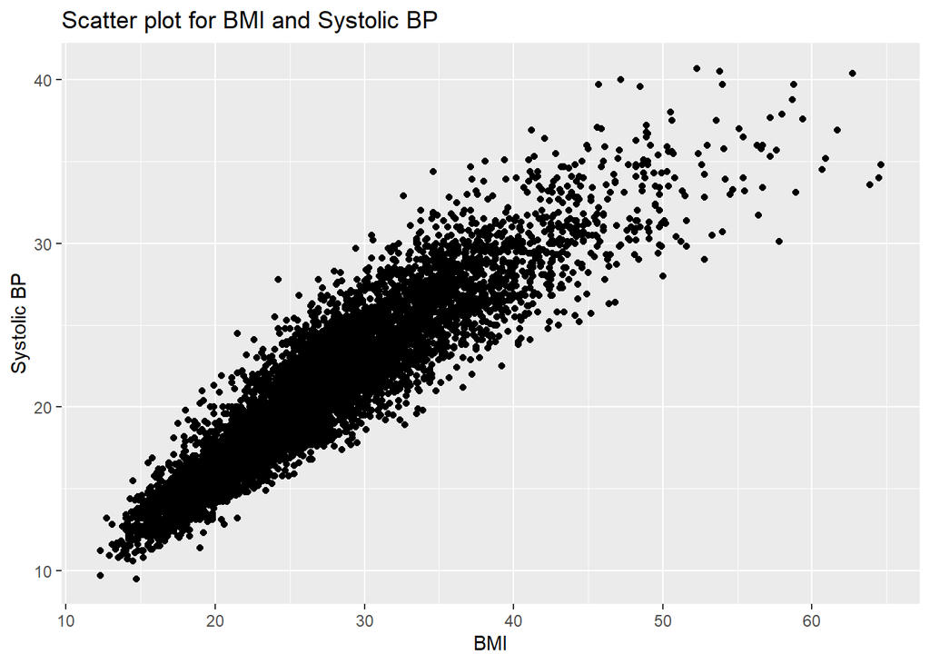

```r
# omit not available
MERGED_DATA_BP <- na.omit(MERGED_DATA[,c("BMXBMI", "BMXSAD1")])

# make a ggplot based on BMXBMI and BMXSAD1
ggplot(MERGED_DATA_BP, aes(x=BMXBMI, y=BMXSAD1)) +
  geom_point() +
  xlab("BMI") +
  ylab("Systolic BP") +
  ggtitle("Scatter plot for BMI and Systolic BP")
```

```r
# make a linear model
BP_LINEAR_MODEL <- lm(BMXSAD1 ~ BMXBMI, data = MERGED_DATA_BP)
summary(BP_LINEAR_MODEL)
```

```
##
## Call:
## lm(formula = BMXSAD1 ~ BMXBMI, data = MERGED_DATA_BP)
##
## Residuals:
##      Min       1Q   Median       3Q      Max
## -10.4505  -1.3060  -0.1892   1.1988   8.6420
##
## Coefficients:
##             Estimate Std. Error t value Pr(>|t|)
## (Intercept)  4.15666    0.09134   45.51   <2e-16 ***
## BMXBMI       0.62432    0.00322  193.89   <2e-16 ***
## ---
## Signif. codes:  0 '***' 0.001 '**' 0.01 '*' 0.05 '.' 0.1 ' ' 1
##
## Residual standard error: 1.983 on 6976 degrees of freedom
## Multiple R-squared:  0.8435, Adjusted R-squared:  0.8435
## F-statistic: 3.759e+04 on 1 and 6976 DF,  p-value: < 2.2e-16
```

```r
MERGED_DATA_CHOLESTEROL <- subset(MERGED_DATA, BMXBMI >= 18.5 & BMXBMI < 25 | BMXBMI >= 25 & BMXBMI < 30 | BMXBMI >= 30)

fit <- lm(BMDBMIC ~ BMXBMI, data = MERGED_DATA_CHOLESTEROL)
anova(fit)
```

```
## Analysis of Variance Table
##
## Response: BMDBMIC
##             Df Sum Sq Mean Sq F value    Pr(>F)
## BMXBMI       1 399.75  399.75  763.97 < 2.2e-16 ***
## Residuals 1697 887.96    0.52
## ---
## Signif. codes:  0 '***' 0.001 '**' 0.01 '*' 0.05 '.' 0.1 ' ' 1
```

#**************************************************************************************************************** #****************************************************************************************************************

#Exercise 3.

#Blood insulin concentrations are an excellent indicator of metabolic health. They are particularly useful for predicting risk of type 2 diabetes in adults. However, insulin is expensive and time consuming to measure. Predicting insulin based on other more easily measured health variables would be of considerable utility in healthcare. Your task is to build a model for predicitng insulin uisng NHANES data.

# 1. Build a multiple linear regression model to predict Insulin (LBDINSI) levels in adults using data from the 2015-2016 NHANES cycle.

# 2. Consider using some or all of the following as predictor variables: BMI, age, gender, waist circumference, DEXA body fat percentage (EXAM), triglyceride (LAB), glucose (LAB).

# 3. You may use any of the other variables avaialble in NHANES 2015-2016 you think can improve the model’s prediction power.

# 3. Choose the best model and justify its choice (2-3 sentences).

# 4. Be sure to check linear regression assumptions on all of the finalised models.

#**************************************************************************************************************** #****************************************************************************************************************

```r
# Browse Available Data
nhanesTables('EXAM', 2015)
```

```
##    Data.File.Name
## 1           BPX_I
## 2           BMX_I
## 3        OHXDEN_I
## 4        OHXREF_I
## 5        FLXCLN_I
## 6           AUX_I
## 7           DXX_I
## 8         AUXAR_I
## 9        AUXTYM_I
## 10       AUXWBR_I
## 11        DXXAG_I
##                                             Data.File.Description
## 1                                                  Blood Pressure
## 2                                                   Body Measures
## 3                                         Oral Health - Dentition
## 4                            Oral Health - Recommendation of Care
## 5                                            Fluorosis - Clinical
## 6                                                      Audiometry
## 7                   Dual-Energy X-ray Absorptiometry - Whole Body
## 8                                    Audiometry - Acoustic Reflex
## 9                                       Audiometry - Tympanometry
## 10                              Audiometry – Wideband Reflectance
## 11 Dual-Energy X-ray Absorptiometry - Android/Gynoid Measurements
```

```r
nhanesTables('LAB', 2015)
```

```
##    Data.File.Name
## 1        UCPREG_I
## 2         FLDEW_I
## 3         FLDEP_I
## 4        UCFLOW_I
## 5           HSV_I
## 6        CHLMDA_I
## 7         TRICH_I
## 8           GHB_I
## 9           CBC_I
## 10       ALB_CR_I
## 11       FASTQX_I
## 12         HEPA_I
## 13       HEPB_S_I
## 14        HEPBD_I
```

[output cut: 151 more lines]

```r
# Get Data
BMX_I <- nhanes('BMX_I')
DEMO_I <- nhanes('DEMO_I')
INS_I <- nhanes('INS_I')
DXX_I <- nhanes('DXX_I')
TRIGLY_I <- nhanes('TRIGLY_I')
GLU_I <- nhanes('GLU_I')
BPX_I <- nhanes('BPX_I')
PAQ_I <- nhanes('PAQ_I')

# Merge Data
NEW_MERGED_DATA1 <- merge(DEMO_I, BMX_I, all = TRUE)
NEW_MERGED_DATA1 <- merge(NEW_MERGED_DATA1, INS_I, all = TRUE)
NEW_MERGED_DATA1 <- merge(NEW_MERGED_DATA1, DXX_I, all = TRUE)
NEW_MERGED_DATA1 <- merge(NEW_MERGED_DATA1, TRIGLY_I, all = TRUE)
NEW_MERGED_DATA1 <- merge(NEW_MERGED_DATA1, GLU_I, all = TRUE)
head(NEW_MERGED_DATA1)
```

```
##    SEQN WTSAF2YR SDDSRVYR RIDSTATR RIAGENDR RIDAGEYR RIDAGEMN RIDRETH1 RIDRETH3
## 1 83732       NA        9        2        1       62       NA        3        3
## 2 83733 54722.34        9        2        1       53       NA        3        3
## 3 83734 25471.09        9        2        1       78       NA        3        3
## 4 83735       NA        9        2        2       56       NA        3        3
## 5 83736 38179.51        9        2        2       42       NA        4        4
## 6 83737 25800.85        9        2        2       72       NA        1        1
##   RIDEXMON RIDEXAGM DMQMILIZ DMQADFC DMDBORN4 DMDCITZN DMDYRSUS DMDEDUC3
## 1        1       NA        2      NA        1        1       NA       NA
## 2        1       NA        2      NA        2        2        7       NA
## 3        2       NA        1       2        1        1       NA       NA
## 4        2       NA        2      NA        1        1       NA       NA
## 5        2       NA        2      NA        1        1       NA       NA
## 6        1       NA        2      NA        2        2        2       NA
##   DMDEDUC2 DMDMARTL RIDEXPRG SIALANG SIAPROXY SIAINTRP FIALANG FIAPROXY
```

[output cut: 125 more lines]

```r
dim(NEW_MERGED_DATA1)
```

```
## [1] 9971  176
```

```r
# Make Model
FIRST_MODEL <- lm(LBDINSI ~ BMXBMI + RIDAGEYR + RIAGENDR + BMXWAIST + LBXTR + LBXGLU + DXDTOFAT, data = NEW_MERGED_DATA1)

# Clean Data
NEW_MERGED_DATA1 <- na.omit(NEW_MERGED_DATA1)

# Display Model
summary(FIRST_MODEL)
```

```
##
## Call:
## lm(formula = LBDINSI ~ BMXBMI + RIDAGEYR + RIAGENDR + BMXWAIST +
##     LBXTR + LBXGLU + DXDTOFAT, data = NEW_MERGED_DATA1)
##
## Residuals:
##     Min      1Q  Median      3Q     Max
## -153.30  -27.68   -5.93   15.99  632.27
##
## Coefficients:
##               Estimate Std. Error t value Pr(>|t|)
## (Intercept) -8.156e+01  1.942e+01  -4.200 2.82e-05 ***
## BMXBMI       2.170e+00  7.255e-01   2.992 0.002820 **
## RIDAGEYR    -1.382e+00  1.200e-01 -11.513  < 2e-16 ***
## RIAGENDR    -1.206e+00  4.002e+00  -0.301 0.763111
## BMXWAIST     1.199e+00  3.086e-01   3.884 0.000107 ***
## LBXTR        1.669e-01  2.004e-02   8.325  < 2e-16 ***
## LBXGLU       5.090e-02  4.498e-02   1.132 0.257923
## DXDTOFAT     3.810e-04  4.439e-04   0.858 0.390851
## ---
## Signif. codes:  0 '***' 0.001 '**' 0.01 '*' 0.05 '.' 0.1 ' ' 1
##
## Residual standard error: 57.53 on 1539 degrees of freedom
##   (8424 observations deleted due to missingness)
## Multiple R-squared:  0.3457, Adjusted R-squared:  0.3428
## F-statistic: 116.2 on 7 and 1539 DF,  p-value: < 2.2e-16
```

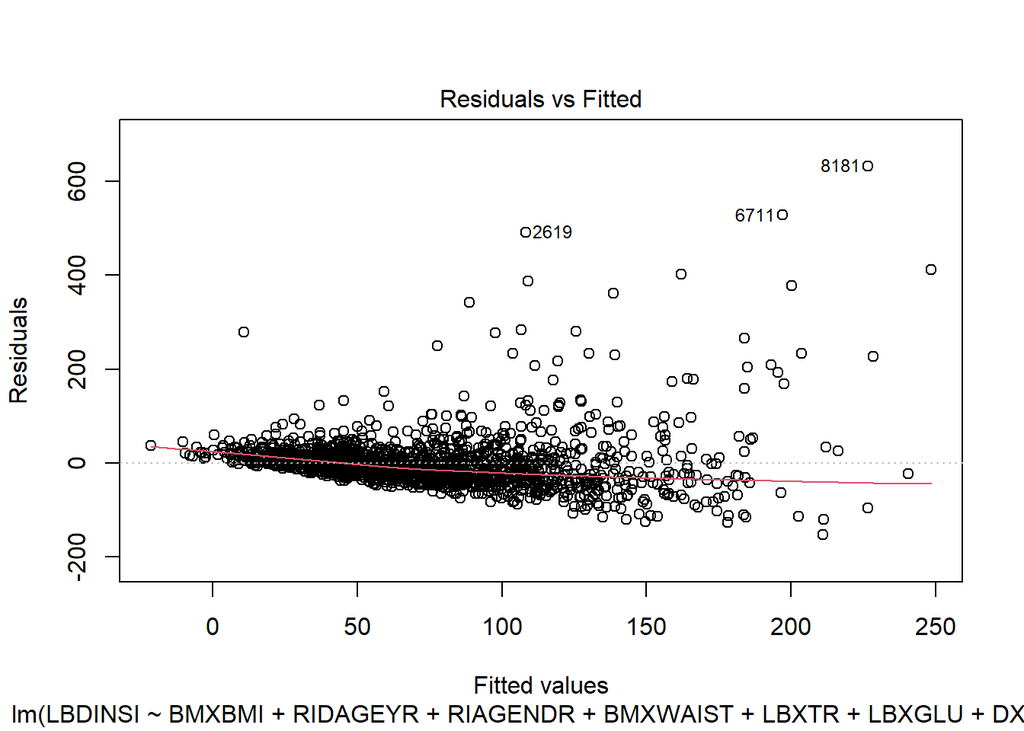

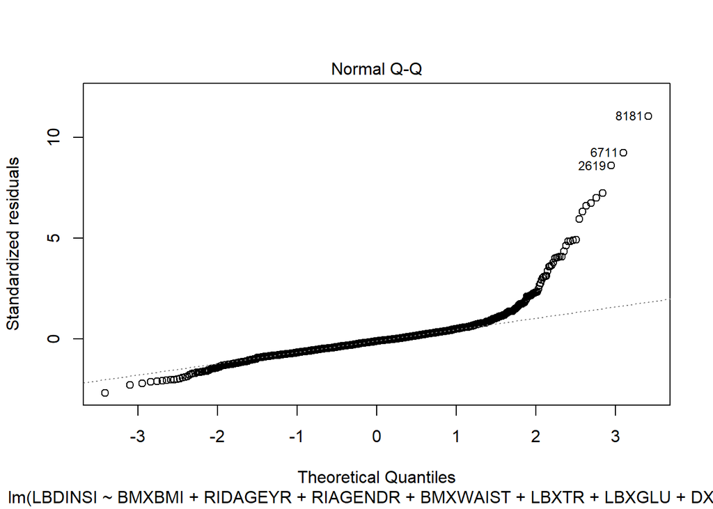

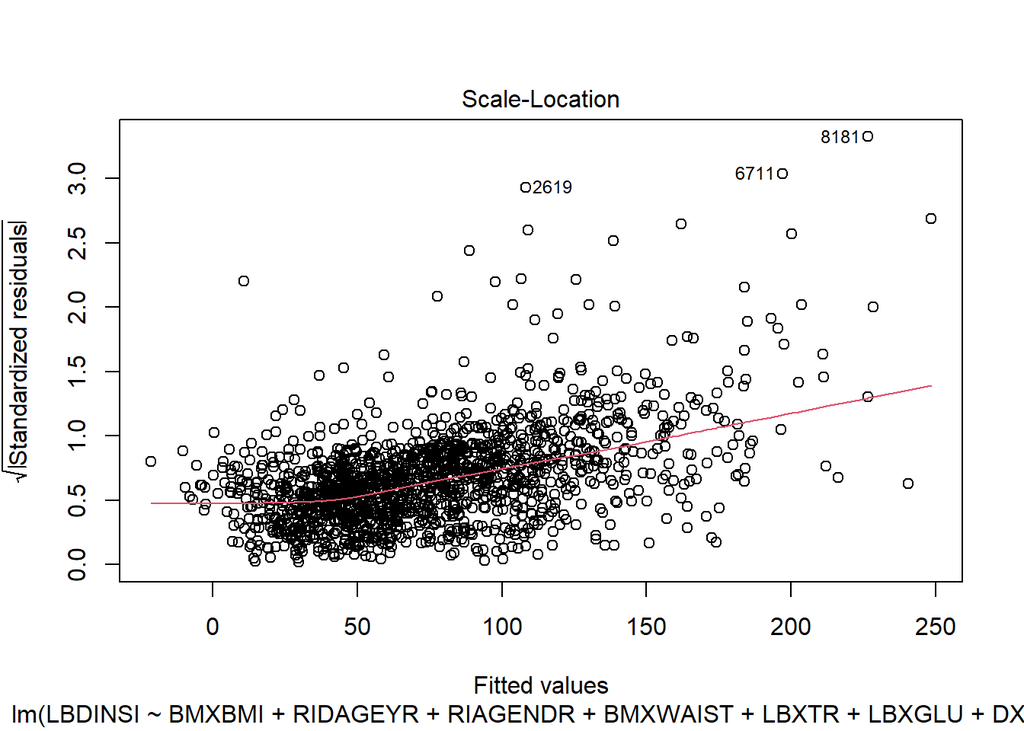

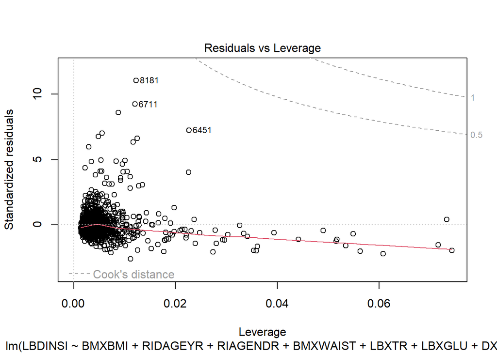

```r
plot(FIRST_MODEL)
```

```r
# Merge Data Again
NEW_MERGED_DATA2 <- merge(DEMO_I, BMX_I, all = TRUE)
NEW_MERGED_DATA2 <- merge(NEW_MERGED_DATA2, INS_I, all = TRUE)
NEW_MERGED_DATA2 <- merge(NEW_MERGED_DATA2, DXX_I, all = TRUE)
NEW_MERGED_DATA2 <- merge(NEW_MERGED_DATA2, TRIGLY_I, all = TRUE)
NEW_MERGED_DATA2 <- merge(NEW_MERGED_DATA2, GLU_I, all = TRUE)
head(NEW_MERGED_DATA2)
```

```
##    SEQN WTSAF2YR SDDSRVYR RIDSTATR RIAGENDR RIDAGEYR RIDAGEMN RIDRETH1 RIDRETH3
## 1 83732       NA        9        2        1       62       NA        3        3
## 2 83733 54722.34        9        2        1       53       NA        3        3
## 3 83734 25471.09        9        2        1       78       NA        3        3
## 4 83735       NA        9        2        2       56       NA        3        3
## 5 83736 38179.51        9        2        2       42       NA        4        4
## 6 83737 25800.85        9        2        2       72       NA        1        1
##   RIDEXMON RIDEXAGM DMQMILIZ DMQADFC DMDBORN4 DMDCITZN DMDYRSUS DMDEDUC3
## 1        1       NA        2      NA        1        1       NA       NA
## 2        1       NA        2      NA        2        2        7       NA
## 3        2       NA        1       2        1        1       NA       NA
## 4        2       NA        2      NA        1        1       NA       NA
## 5        2       NA        2      NA        1        1       NA       NA
## 6        1       NA        2      NA        2        2        2       NA
##   DMDEDUC2 DMDMARTL RIDEXPRG SIALANG SIAPROXY SIAINTRP FIALANG FIAPROXY
```

[output cut: 125 more lines]

```r
dim(NEW_MERGED_DATA2)
```

```
## [1] 9971  176
```

```r
# Make Model
SECOND_MODEL <- lm(LBDINSI ~ BMXBMI + RIDAGEYR + RIAGENDR + BMXWAIST + LBXTR + LBXGLU + DXDTOFAT, data = NEW_MERGED_DATA2)

# Clean Data
NEW_MERGED_DATA2 <- na.omit(NEW_MERGED_DATA2)

# Display Model
summary(SECOND_MODEL)
```

```
##
## Call:
## lm(formula = LBDINSI ~ BMXBMI + RIDAGEYR + RIAGENDR + BMXWAIST +
##     LBXTR + LBXGLU + DXDTOFAT, data = NEW_MERGED_DATA2)
##
## Residuals:
##     Min      1Q  Median      3Q     Max
## -153.30  -27.68   -5.93   15.99  632.27
##
## Coefficients:
##               Estimate Std. Error t value Pr(>|t|)
## (Intercept) -8.156e+01  1.942e+01  -4.200 2.82e-05 ***
## BMXBMI       2.170e+00  7.255e-01   2.992 0.002820 **
## RIDAGEYR    -1.382e+00  1.200e-01 -11.513  < 2e-16 ***
## RIAGENDR    -1.206e+00  4.002e+00  -0.301 0.763111
## BMXWAIST     1.199e+00  3.086e-01   3.884 0.000107 ***
## LBXTR        1.669e-01  2.004e-02   8.325  < 2e-16 ***
## LBXGLU       5.090e-02  4.498e-02   1.132 0.257923
## DXDTOFAT     3.810e-04  4.439e-04   0.858 0.390851
## ---
## Signif. codes:  0 '***' 0.001 '**' 0.01 '*' 0.05 '.' 0.1 ' ' 1
##
## Residual standard error: 57.53 on 1539 degrees of freedom
##   (8424 observations deleted due to missingness)
## Multiple R-squared:  0.3457, Adjusted R-squared:  0.3428
## F-statistic: 116.2 on 7 and 1539 DF,  p-value: < 2.2e-16
```

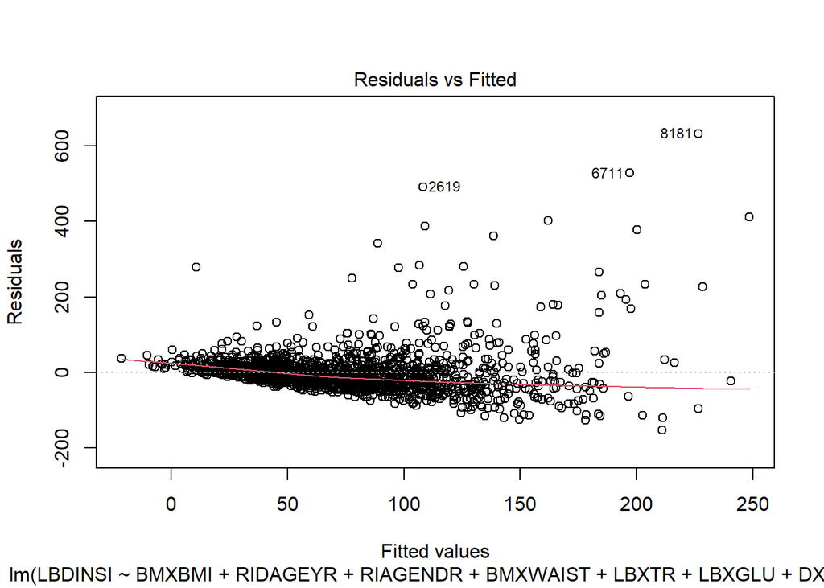

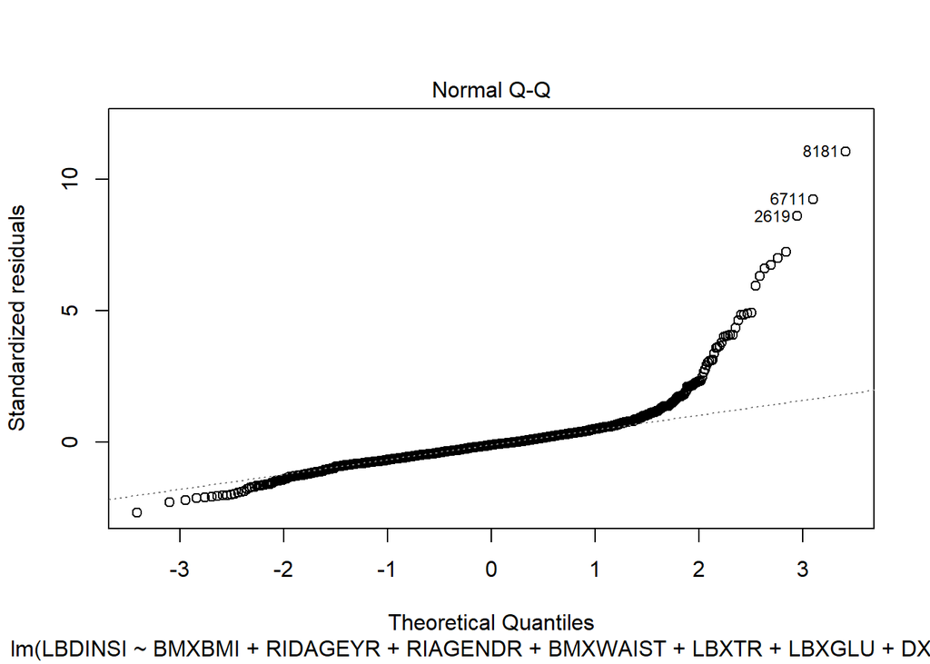

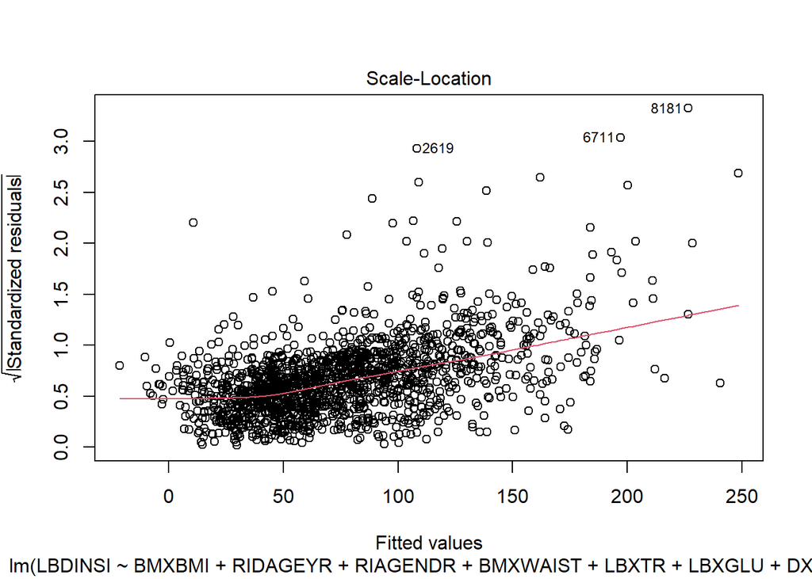

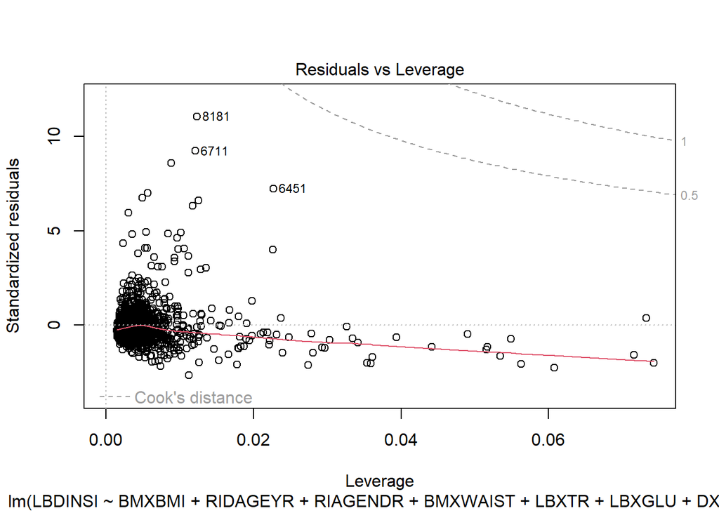

```r
plot(SECOND_MODEL)
```

```r
# Merge Data Again
NEW_MERGED_DATA3 <- merge(DEMO_I, BMX_I, all = TRUE)
NEW_MERGED_DATA3 <- merge(NEW_MERGED_DATA3, INS_I, all = TRUE)
NEW_MERGED_DATA3 <- merge(NEW_MERGED_DATA3, DXX_I, all = TRUE)
NEW_MERGED_DATA3 <- merge(NEW_MERGED_DATA3, TRIGLY_I, all = TRUE)
NEW_MERGED_DATA3 <- merge(NEW_MERGED_DATA3, GLU_I, all = TRUE)
NEW_MERGED_DATA3 <- merge(NEW_MERGED_DATA3, BPX_I, all = TRUE)
NEW_MERGED_DATA3 <- merge(NEW_MERGED_DATA3, PAQ_I, all = TRUE)
head(NEW_MERGED_DATA3)
```

```
##    SEQN WTSAF2YR SDDSRVYR RIDSTATR RIAGENDR RIDAGEYR RIDAGEMN RIDRETH1 RIDRETH3
## 1 83732       NA        9        2        1       62       NA        3        3
## 2 83733 54722.34        9        2        1       53       NA        3        3
## 3 83734 25471.09        9        2        1       78       NA        3        3
## 4 83735       NA        9        2        2       56       NA        3        3
## 5 83736 38179.51        9        2        2       42       NA        4        4
## 6 83737 25800.85        9        2        2       72       NA        1        1
##   RIDEXMON RIDEXAGM DMQMILIZ DMQADFC DMDBORN4 DMDCITZN DMDYRSUS DMDEDUC3
## 1        1       NA        2      NA        1        1       NA       NA
## 2        1       NA        2      NA        2        2        7       NA
## 3        2       NA        1       2        1        1       NA       NA
## 4        2       NA        2      NA        1        1       NA       NA
## 5        2       NA        2      NA        1        1       NA       NA
## 6        1       NA        2      NA        2        2        2       NA
##   DMDEDUC2 DMDMARTL RIDEXPRG SIALANG SIAPROXY SIAINTRP FIALANG FIAPROXY
```

[output cut: 209 more lines]

```r
dim(NEW_MERGED_DATA3)
```

```
## [1] 9971  289
```

```r
# Fill Model
THIRD_MODEL <- lm(LBDINSI ~ BMXBMI + RIDAGEYR + RIAGENDR + BMXWAIST + LBXTR + LBXGLU + DXDTOFAT + BPXDI3 + BPXSY3 , data = NEW_MERGED_DATA3)

# Clean Data
NEW_MERGED_DATA3 <- na.omit(NEW_MERGED_DATA3)

# Display Model
summary(THIRD_MODEL)
```

```
##
## Call:
## lm(formula = LBDINSI ~ BMXBMI + RIDAGEYR + RIAGENDR + BMXWAIST +
##     LBXTR + LBXGLU + DXDTOFAT + BPXDI3 + BPXSY3, data = NEW_MERGED_DATA3)
##
## Residuals:
##     Min      1Q  Median      3Q     Max
## -155.71  -28.25   -6.20   16.19  633.00
##
## Coefficients:
##               Estimate Std. Error t value Pr(>|t|)
## (Intercept) -8.846e+01  2.229e+01  -3.968 7.58e-05 ***
## BMXBMI       2.169e+00  7.453e-01   2.910 0.003665 **
## RIDAGEYR    -1.396e+00  1.306e-01 -10.684  < 2e-16 ***
## RIAGENDR    -6.507e-01  4.133e+00  -0.157 0.874927
## BMXWAIST     1.228e+00  3.166e-01   3.879 0.000109 ***
## LBXTR        1.657e-01  2.059e-02   8.048 1.69e-15 ***
## LBXGLU       4.525e-02  4.577e-02   0.989 0.322972
## DXDTOFAT     3.696e-04  4.558e-04   0.811 0.417560
## BPXDI3      -8.020e-02  1.391e-01  -0.577 0.564210
## BPXSY3       8.720e-02  1.201e-01   0.726 0.467944
## ---
## Signif. codes:  0 '***' 0.001 '**' 0.01 '*' 0.05 '.' 0.1 ' ' 1
##
## Residual standard error: 58.04 on 1495 degrees of freedom
##   (8466 observations deleted due to missingness)
## Multiple R-squared:  0.3428, Adjusted R-squared:  0.3389
## F-statistic: 86.65 on 9 and 1495 DF,  p-value: < 2.2e-16
```